# Child Care Center Closures

# Overview

The purpose of this research is to explore child care center and family child care home closures in 2020 to gauge if and how Covid-19 affected closures. This research question was lifted by F5LA and might be incorporated into our F5LA deliverable.

For this research, I pulled child care center and family child care home data from the [California Department of Social Services (CDSS) page](https://www.ccld.dss.ca.gov/carefacilitysearch/DownloadData). The data was last downloaded on 01/07/21 and is updated on the CDSS page weekly.

It is important to note that using the licensing data has limitations. Data from the CDSS page only reflects permanent facility closures. These are facilities that no longer have a license to operate. For the purposes of this analysis, facilities that are pending having their licenses approved are also considered closed.

The CDSS data does not show the reason a facility permanently closed. Many facilities have had to close due to new Covid-19 guidelines, or a decrease in enrollment and funding. However, these closures could be excluded from this data because the facility owners can still have their license but cease operations. These type of closures can be thought of as ‘temporary closures’ because the facility owners still have a license. Temporary closures are not captured in the data, resulting in an under-representation of facilities that are no longer providing services to families.

**While this research focuses on permanently closed facilities, the facilities that are open are being impacted by Covid-19.** [Anecdotes from providers and families](https://www.advancementprojectca.org/blog) reveal that many facilities are heavily impacted by Covid-19, which the data might not accurately capture. [Women of color and immigrant women](https://nwlc-ciw49tixgw5lbab.stackpathdns.com/wp-content/uploads/2020/08/ChildCareWorkersFS.pdf) in particular, who disproportionately represent child care workers, are shouldering the burden for providing early learning and care to families.

For more information on how Covid-19 has been impacting child care in California and Los Angeles, please refer to the Center for the Study of Child Care and Employment’s (CSCCE) [survey of licensed child care centers and licensed family child care programs](https://cscce.berkeley.edu/regional-snapshot-california-child-care-at-the-brink-covid-19/).

- The survey results show that family child care homes and child care centers in Los Angeles are facing significant financial challenges and staffing changes as a result of Covid-19.
- Over 70% of centers reported that families are unable to pay for childcare due to loss of income
- Majority of centers report difficulty in affording sanitizing supplies and PPE for staff.

**DISCLAIMER: All data visualizations and analyses have not been QAed yet.**

# Map of Permanent Closures

Below shows the child care facilities and family home care centers that have closed permanently in 2020. Please note that for family home care centers, addresses for each facility was not available. Family home care centers are plotted by the state, city and zip code information. Child care facilities are plotted based on the facility address.

[interactive chart not shown]

# Summary of Findings

*Child Care Centers*

- More Child Care Centers closed permanently in 2019 compared to 2020 in both California and Los Angeles County
- There was a huge spike in child care center closures in June of 2020 in California, resulting in a substantial number of seats lost. Los Angeles County did not experience the same drastic spike.
- Compared to California, Los Angeles County has fewer closures and seats lost.
- In Los Angeles County, permanent closures decreased in April of 2020.

*Family Care Centers*

- Family Child Care Centers in California experienced a spike in closures and seats lost in August of 2020
- Both Los Angeles County and California experienced a decrease in closures in April of 2020, similar with Child Care Centers
- The difference between California and Los Angeles County closures and seats lost is lower compared to the California and Los Angeles County child care centers.

Summary of Permanent Closures and Seats Lost

[output not shown]

# Child Care Centers

## Closures

### Closures in 2020 by month

[interactive chart not shown]

### Closures in 2020 by day

[interactive chart not shown]

### Closures in 2019 vs. 2020

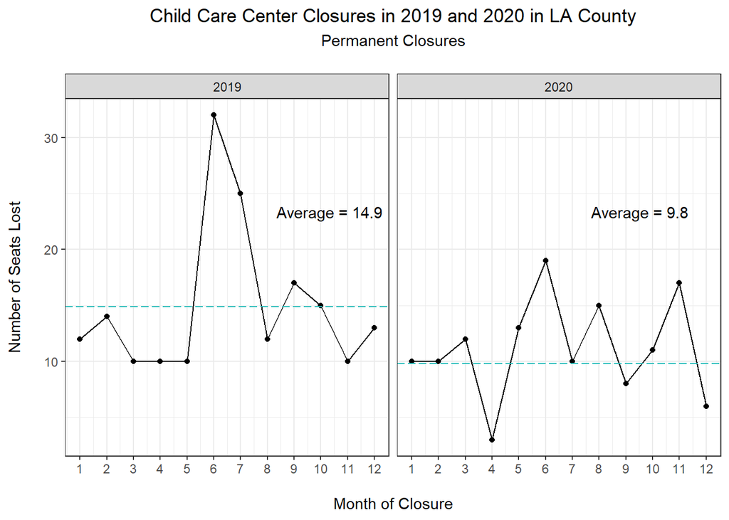

## Seats Lost

### Seats lost in 2020 by month

[interactive chart not shown]

### Seats lost in 2020 by day

[interactive chart not shown]

### Seats lost in 2019 vs. 2020

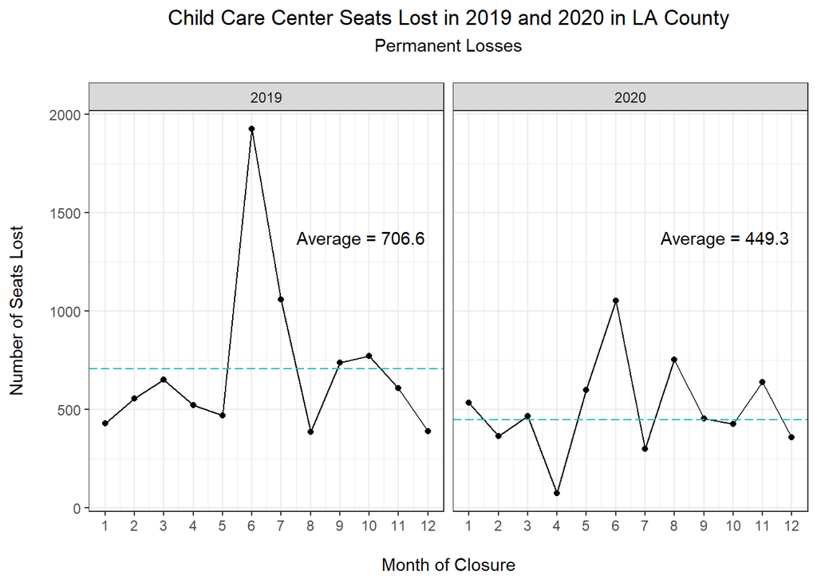

# Family Child Care Homes

## Closures

### Closures in 2020 by month

[interactive chart not shown]

### Closures in 2020 by day

[interactive chart not shown]

### Closures in 2019 vs. 2020

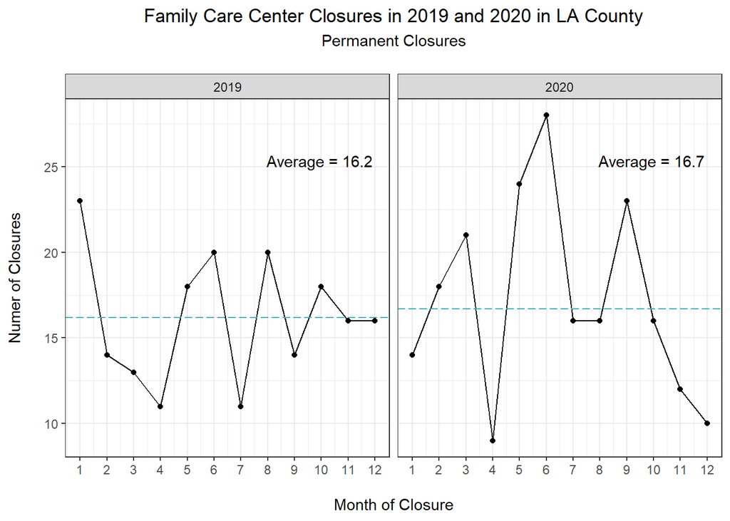

## Seats

### Seats Lost in 2020 by month

[interactive chart not shown]

### Seats Lost in 2020 by day

[interactive chart not shown]

### Seats Lost in 2019 vs. 2020

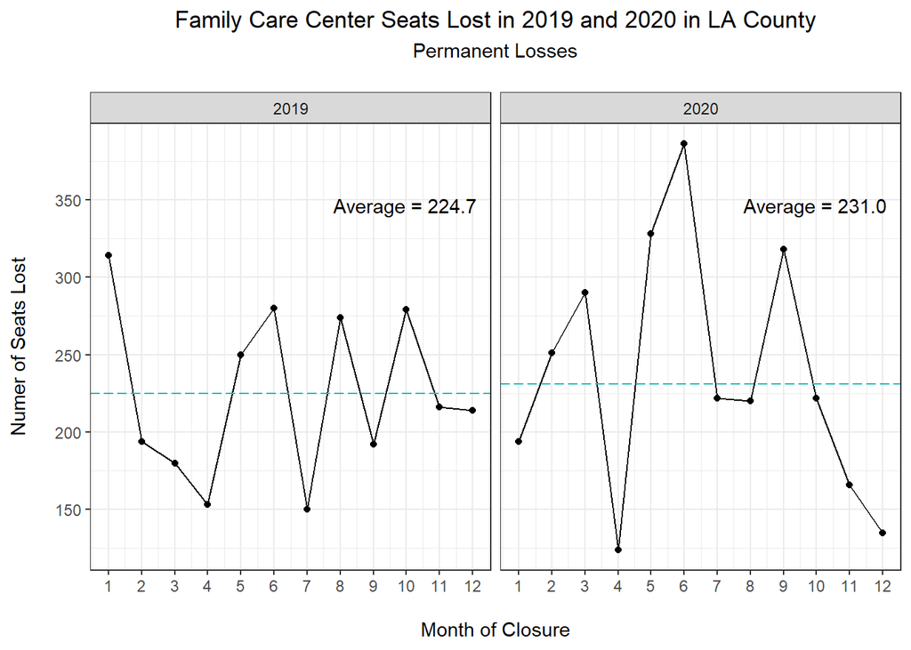